# Assignment 1

Nattanan

2024-09-17

## 1 Create a data frame

Step 1. Within RStudio, find the Console window. In the Console, write a command to create a vector called animals which contains the names of a few animals. What type of vector is this? Your vector might look something like this:  
## [1] “Snake” “Ostrich” “Cat” “Spider”

```r
animals <- c("Snake", "Ostrich", "Cat" , "Spider")
animals
```

```
## [1] "Snake"   "Ostrich" "Cat"     "Spider"
```

```r
mode(animals)
```

```
## [1] "character"
```

Step 2. Create a vector of the same length called num_legs which gives the number of legs of the different animals. Your second vector will look something like this:  
## [1] 0 2 4 8

```r
num_legs <- c(0, 2, 4, 8)
num_legs
```

```
## [1] 0 2 4 8
```

Step 3. Now combine these two vectors in a data frame called animals_df which has two columns - one with the names of animals, and another with their respective numbers of legs. The result should look something like this:  
## animals num_legs  
## 1 Snake 0  
## 2 Ostrich 2  
## 3 Cat 4  
## 4 Spider 8

```r
animals_df <- data.frame(animals, num_legs)
animals_df
```

```
##   animals num_legs
## 1   Snake        0
## 2 Ostrich        2
## 3     Cat        4
## 4  Spider        8
```

## 2 Check and delete objects

Apart from creating objects, you can also check and delete them. In this question, you will also learn how to find help documents of R functions  
Step 1. After you finish creating the data frame required by Question 1, get a list of objects in the working environment.

```r
ls()
```

```
## [1] "animals"    "animals_df" "num_legs"
```

Step 2. Use the function rm (type ?rm to see examples of using rm) to remove the objects num legs from the working environment. After that, check the list of objects in the current environment again, to see if num legs has been removed.

```r
rm(num_legs)
ls()
```

```
## [1] "animals"    "animals_df"
```

Step 3. Remove all objects in the working environment.

```r
rm(animals, animals_df)
ls()
```

```
## character(0)
```

## 5 Matrix operations

Use the seq() function to generate a sequence of numbers starting at 12 and decreasing to 2 in steps of -2. Call this vector x_vect. You may want to run ?seq or help(seq) to help you do this. The vector x_vect should look like this:  
## [1] 12 10 8 6 4 2

```r
x_vect <- seq(12,2,-2)
x_vect
```

```
## [1] 12 10  8  6  4  2
```

Now convert the vector x_vect into a matrix (with 2 rows and 3 coloumns) called X, using the matrix() function. The result should look like this:  
## [,1] [,2] [,3]  
## [1,] 12 8 4  
## [2,] 10 6 2

```r
X <- matrix(x_vect, 2, 3)
X
```

```
##      [,1] [,2] [,3]
## [1,]   12    8    4
## [2,]   10    6    2
```

Next create a 2 by 2 matrix called Y consisting of a sequence of four numbers from 1-4. The matrix Y should look like this:  
## [,1] [,2]  
## [1,] 1 3  
## [2,] 2 4

```r
y_vect <- seq(1, 4)
Y <- matrix(y_vect, 2, 2)
Y
```

```
##      [,1] [,2]
## [1,]    1    3
## [2,]    2    4
```

In addition, create another 2 by 2 matrix called Z which looks as follows:  
## [,1] [,2]  
## [1,] 4 8  
## [2,] 6 10

```r
z_vect <- seq(4, 10, 2)
Z <- matrix(z_vect, 2, 2)
Z
```

```
##      [,1] [,2]
## [1,]    4    8
## [2,]    6   10
```

Use the t() function to compute Y<sup>T</sup> and Z<sup>T</sup>

```r
t(Y)
```

```
##      [,1] [,2]
## [1,]    1    2
## [2,]    3    4
```

```r
t(Z)
```

```
##      [,1] [,2]
## [1,]    4    6
## [2,]    8   10
```

Matrix sums. Now compute the matrix sums Y + Z and Y + Z. The result in both cases should be the same. We call such operations commutative. This means that reversing the order does not change the result.

```r
Y + Z
```

```
##      [,1] [,2]
## [1,]    5   11
## [2,]    8   14
```

```r
Z + Y
```

```
##      [,1] [,2]
## [1,]    5   11
## [2,]    8   14
```

Matrix multiplication. Use R to compute the matrix products Y Z and ZY . Are the results the same in both cases? Is matrix multiplication commutative?

```r
Y*Z
```

```
##      [,1] [,2]
## [1,]    4   24
## [2,]   12   40
```

```r
Z*Y
```

```
##      [,1] [,2]
## [1,]    4   24
## [2,]   12   40
```

Matrix inverse. Compute the matrix inverse Y<sup>−1</sup> via the solve() function:  
solve(Y)  
You should get something like this  
## [,1] [,2]  
## [1,] -2 1.5  
## [2,] 1 -0.5

```r
solve(Y)
```

```
##      [,1] [,2]
## [1,]   -2  1.5
## [2,]    1 -0.5
```

## 6 Writing a function within R

First, create an R script (see also Question 3), and saving it using the name mySecondRScript. To do the following steps, it is good to know how a function is defined in R as well as basic control flow statements in R (e.g., if…else…, and for). You may want to first look at the sample function called is prime (provided at the end of this question) for function definition and control flow statements, before you continue.

Step 1. Within your script create a short function called myFirstRFunc which takes in a single numerical argument n and outputs the sum of all those numbers strictly below n which are divisible by either 2 or 7 or both.  
For example, if n = 14 then it should be the sum of 2, 4, 6, 7, 8, 10, 12, so myFirstRFunc applied to 14 gives the answer 2 + 4 + 6 + 7 + 8 + 10 + 12 = 49. Make sure your function includes useful comments. You may want to include a check so that your function produces an error if it is given an argument which isn’t a non-negative integer.

```r
myFirstRFunc <- function(x){
  i <- 1
  num <- c()
  while(i < x){
    if (i%%2 == 0 | i%%7 == 0){
      num <- append(num, i)
    }
    i <- i+1
  }
  total <- sum(num)
  print(total)
}

myFirstRFunc(14)
```

```
## [1] 49
```

Step 2. Run the script by clicking on the “Source” button on the top right. Then check what you get if you apply the function to 1000, i.e., myFirstRFunc(1000) If you have been successful your function should produce the following output.  
## [1] 284787

```r
myFirstRFunc(1000)
```

```
## [1] 284787
```

## 7 Futher R Markdown exercises

Step 1. Within your R markdown insert a section heading called “Wave plot”.

### Wave plot

Step 2. Insert a code block to do the following. • Define a vector called x consisting of a sequence which starts at 0 and goes to 20 in increments of 0.01. You can do this using the seq() function. • Next create a vector called y, which is of the same length as x, such that the i<sup>th</sup> entry of y is equal to the sin function of the i<sup>th</sup> entry of x. This can be done via the R function sin(). • Then create a data frame called sin df with two columns: x and y. You can inspect the first few rows of your data frame with the head() function like this: head(sin_df,3) ## x y ## 1 0.00 0.000000000 ## 2 0.01 0.009999833 ## 3 0.02 0.019998667

```r
 x <- seq(0, 20, 0.01)
 y <- sin(x)
 sin_df <- data.frame(x,y)
 head(sin_df, 3)
```

```
##      x           y
## 1 0.00 0.000000000
## 2 0.01 0.009999833
## 3 0.02 0.019998667
```

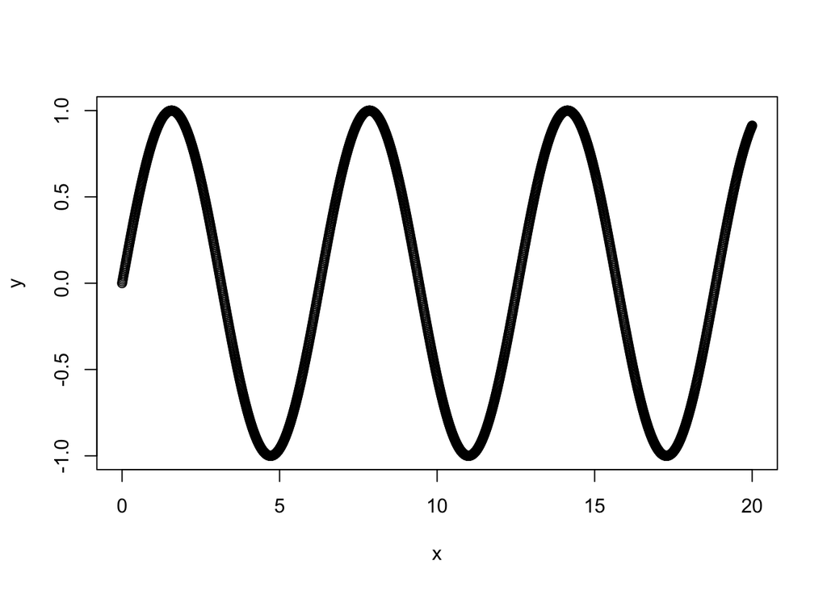

```r
plot(sin_df)
```

Step 3. Insert the following mathematical formula into your Markdown file: sin<sup>2</sup>(x) + cos<sup>2</sup>(x) = 1.